# Linear regression in R

Erin Shellman

April 13 & 20, 2015

## Linear regression

In this tutorial we’ll learn:

- how to `merge` datasets
- how to fit linear regression models
- how to split data into test and train sets
- how to tune our models and select features

### Data preparation

We’re working with the Capital Bikeshare again this week, so start by reading in *usage*, *weather*, *stations*.

```r
library(dplyr)
library(ggplot2)
library(lubridate)

usage = read.delim('usage_2012.tsv',
                   sep = '\t',
                   header = TRUE)

weather = read.delim('daily_weather.tsv',
                   sep = '\t',
                   header = TRUE)

stations = read.delim('stations.tsv',
                   sep = '\t',
                   header = TRUE)
```

### Merging data

We have three related datasets to work with, but we can’t really get started until they’re combined. Let’s start with *usage* and *weather*. The *usage* dataframe is at the resolution of the hour, while the *weather* data are at the resolution of a day, so we know we’re going to have to either duplicate or compress data to merge. I vote compress, let’s summarize!

```r
head(usage)
```

```
##   bike_id          time_start            time_end duration_mins
## 1  W01412 2012-01-01 00:04:00 2012-01-01 00:11:00             7
## 2  W00524 2012-01-01 00:10:00 2012-01-01 00:29:00            19
## 3  W00235 2012-01-01 00:10:00 2012-01-01 00:29:00            19
## 4  W00864 2012-01-01 00:15:00 2012-01-01 00:23:00             8
## 5  W00995 2012-01-01 00:15:00 2012-01-01 00:23:00             8
## 6  W00466 2012-01-01 00:17:00 2012-01-01 00:23:00             6
##                          station_start             station_end  cust_type
## 1         7th & R St NW / Shaw Library           7th & T St NW Registered
## 2       Georgia & New Hampshire Ave NW    16th & Harvard St NW     Casual
## 3       Georgia & New Hampshire Ave NW    16th & Harvard St NW Registered
## 4                       14th & V St NW Park Rd & Holmead Pl NW Registered
## 5                  11th & Kenyon St NW           7th & T St NW Registered
## 6 Court House Metro / 15th & N Uhle St    Lynn & 19th St North Registered
```

```r
custs_per_day =
  usage %>%
    group_by(time_start = as.Date(time_start), station_start, cust_type) %>%
    summarize(no_rentals = n(),
              duration_mins = mean(duration_mins, na.rm = TRUE))

head(custs_per_day)
```

```
## Source: local data frame [6 x 5]
## Groups: time_start, station_start
##
##   time_start                 station_start  cust_type no_rentals
## 1 2012-01-01           10th & Monroe St NE Registered         10
## 2 2012-01-01                10th & U St NW     Casual          8
## 3 2012-01-01                10th & U St NW Registered         50
## 4 2012-01-01 10th St & Constitution Ave NW     Casual         34
## 5 2012-01-01 10th St & Constitution Ave NW Registered         20
## 6 2012-01-01                11th & H St NE     Casual          4
## Variables not shown: duration_mins (dbl)
```

Perfection, now we can merge! What’s the key?

```r
# make sure we have consistent date formats
custs_per_day$time_start = ymd(custs_per_day$time_start)
weather$date = ymd(weather$date)

# then merge. see ?merge for more details about the function
weather_rentals = merge(custs_per_day, weather,
                        by.x = 'time_start', by.y = 'date')

# check dimensions after to make sure they are what you expect
dim(custs_per_day)
```

```
## [1] 99356     5
```

```r
dim(weather)
```

```
## [1] 366  15
```

```r
dim(weather_rentals)
```

```
## [1] 99356    19
```

```r
head(weather_rentals)
```

```
##   time_start                 station_start  cust_type no_rentals
## 1 2012-01-01           10th & Monroe St NE Registered         10
## 2 2012-01-01                10th & U St NW     Casual          8
## 3 2012-01-01                10th & U St NW Registered         50
## 4 2012-01-01 10th St & Constitution Ave NW     Casual         34
## 5 2012-01-01 10th St & Constitution Ave NW Registered         20
## 6 2012-01-01                11th & H St NE     Casual          4
##   duration_mins weekday season_code season_desc is_holiday is_work_day
## 1      16.40000       0           1      Spring          0           0
## 2      16.25000       0           1      Spring          0           0
## 3      10.00000       0           1      Spring          0           0
## 4      20.29412       0           1      Spring          0           0
## 5      14.20000       0           1      Spring          0           0
## 6      10.00000       0           1      Spring          0           0
##   weather_code                                    weather_desc temp
```

[output cut: 20 more lines]

Great, now we want to merge on the last dataset, *stations*. What is the key to link *weather_rentals* with *stations*?

```r
final_data = merge(weather_rentals, stations,
                   by.x = 'station_start', by.y = 'station')
dim(final_data)
```

```
## [1] 98634   154
```

```r
dim(weather_rentals)
```

```
## [1] 99356    19
```

```r
head(final_data[, 1:30])
```

```
##    station_start time_start  cust_type no_rentals duration_mins weekday
## 1 10th & E St NW 2012-07-25     Casual          8      82.37500       3
## 2 10th & E St NW 2012-07-25 Registered         32      13.28125       3
## 3 10th & E St NW 2012-11-13 Subscriber         19      11.73684       2
## 4 10th & E St NW 2012-09-25 Registered         41      12.29268       2
## 5 10th & E St NW 2012-08-09 Registered         34      13.61765       4
## 6 10th & E St NW 2012-11-22 Subscriber          7      12.14286       4
##   season_code season_desc is_holiday is_work_day weather_code
## 1           3        Fall          0           1            1
## 2           3        Fall          0           1            1
## 3           4      Winter          0           1            2
## 4           4      Winter          0           1            1
## 5           3        Fall          0           1            1
## 6           4      Winter          1           0            1
##                                                   weather_desc     temp
```

[output cut: 27 more lines]

```r
# probably want to save this now!
write.table(final_data,
            'bikeshare_modeling_data.tsv',
            row.names = FALSE, sep = '\t')

# rename to something more convenient and remove from memory
data = final_data
rm(final_data)
```

### The `lm()` function

The function for creating a linear model in R is `lm()` and the primary arguments are *formula* and *data*. Formulas in R are a little funny, instead of an = sign, they are expressed with a ~. Let’s fit the model we saw in the lecture notes: $rentals = \beta_0 + \beta_1*crossing$. There’s a little snag we have to take care of first. Right now we’ve got repeated measures *i.e.* one measurement per day, so we need to aggregate again this time over date.

```r
rentals_crossing =
  data %>%
    group_by(station_start) %>%
    summarize(mean_rentals = mean(no_rentals),
              crossing = mean(crossing))

head(rentals_crossing)
```

```
## Source: local data frame [6 x 3]
##
##                   station_start mean_rentals crossing
## 1                10th & E St NW    19.003003      122
## 2           10th & Monroe St NE     7.580517        1
## 3                10th & U St NW    37.954876        5
## 4 10th St & Constitution Ave NW    28.430362      116
## 5                11th & H St NE    20.121875       73
## 6           11th & Kenyon St NW    33.718331       20
```

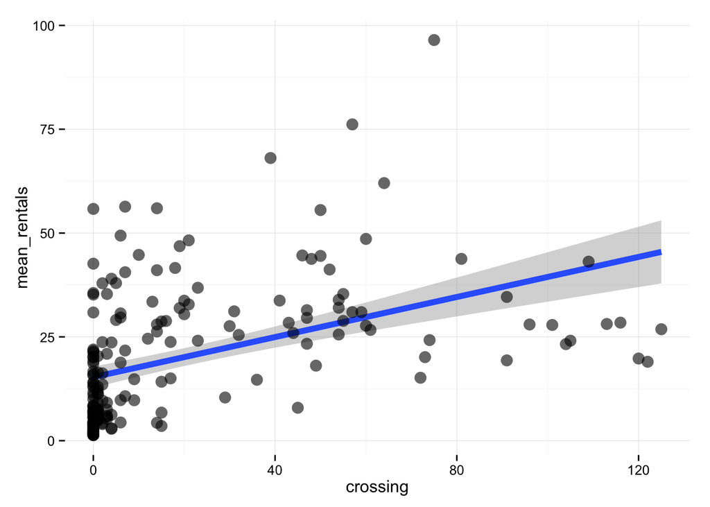

```r
# plot it
ggplot(rentals_crossing, aes(x = crossing, y = mean_rentals)) +
  geom_smooth(method = 'lm', size = 2) +
  geom_point(size = 4, alpha = 0.60) +
  theme_minimal()
```

```r
model = lm(mean_rentals ~ crossing, data = rentals_crossing)

# view what is returned in the lm object
attributes(model)
```

```
## $names
##  [1] "coefficients"  "residuals"     "effects"       "rank"
##  [5] "fitted.values" "assign"        "qr"            "df.residual"
##  [9] "xlevels"       "call"          "terms"         "model"
##
## $class
## [1] "lm"
```

```r
# get model output
summary(model)
```

```
##
## Call:
## lm(formula = mean_rentals ~ crossing, data = rentals_crossing)
##
## Residuals:
##     Min      1Q  Median      3Q     Max
## -25.735 -10.767  -4.190   6.755  63.079
##
## Coefficients:
##             Estimate Std. Error t value Pr(>|t|)
## (Intercept) 15.30402    1.29989  11.773  < 2e-16 ***
## crossing     0.24127    0.03524   6.846 1.11e-10 ***
## ---
## Signif. codes:  0 '***' 0.001 '**' 0.01 '*' 0.05 '.' 0.1 ' ' 1
##
## Residual standard error: 14.8 on 183 degrees of freedom
## Multiple R-squared:  0.2039, Adjusted R-squared:  0.1996
## F-statistic: 46.87 on 1 and 183 DF,  p-value: 1.109e-10
```

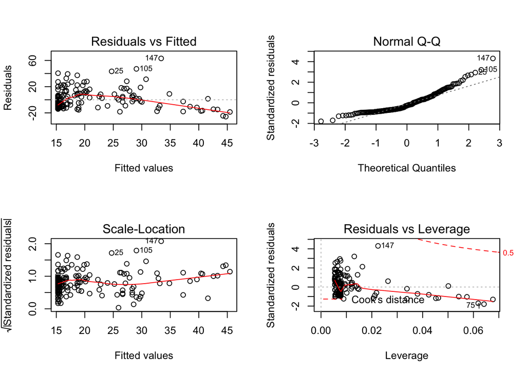

```r
# print model diagnostics
par(mfrow = c(2, 2))
plot(model)
```

The `attributes()` function can be called on just about any object in R and it returns a list of all the things inside. It’s a great way to explore objects and see what values are contained inside that could be used in other analysis. For example, extracting the residuals via `model$residuals` is useful if we want to print diagnostic plots like those above.

When we run `summary()` on the `lm` object, we see the results. The *Call* section just prints back the model specification, and the *Residuals* section contains a summary of the distribution of the errors. The fun stuff is in the *Coefficients* section. In the first row contains the covariate names followed by their estimates, standard errors, t- and p-values. Our model ends up being `rentals = 15 + 0.24(crosswalks)` which means that the average number of rentals when there are no crosswalks is 15, and the average increases by 1 rental for every four additional crosswalks.

We can fit regressions with multiple covariates the same way:

```r
# lets include windspeed this time
rentals_multi =
  data %>%
    group_by(station_start) %>%
    summarize(mean_rentals = mean(no_rentals),
              crossing = mean(crossing),
              windspeed = mean(windspeed))

head(rentals_multi)
```

```
## Source: local data frame [6 x 4]
##
##                   station_start mean_rentals crossing windspeed
## 1                10th & E St NW    19.003003      122 0.1731664
## 2           10th & Monroe St NE     7.580517        1 0.1866016
## 3                10th & U St NW    37.954876        5 0.1890061
## 4 10th St & Constitution Ave NW    28.430362      116 0.1886993
## 5                11th & H St NE    20.121875       73 0.1889982
## 6           11th & Kenyon St NW    33.718331       20 0.1882405
```

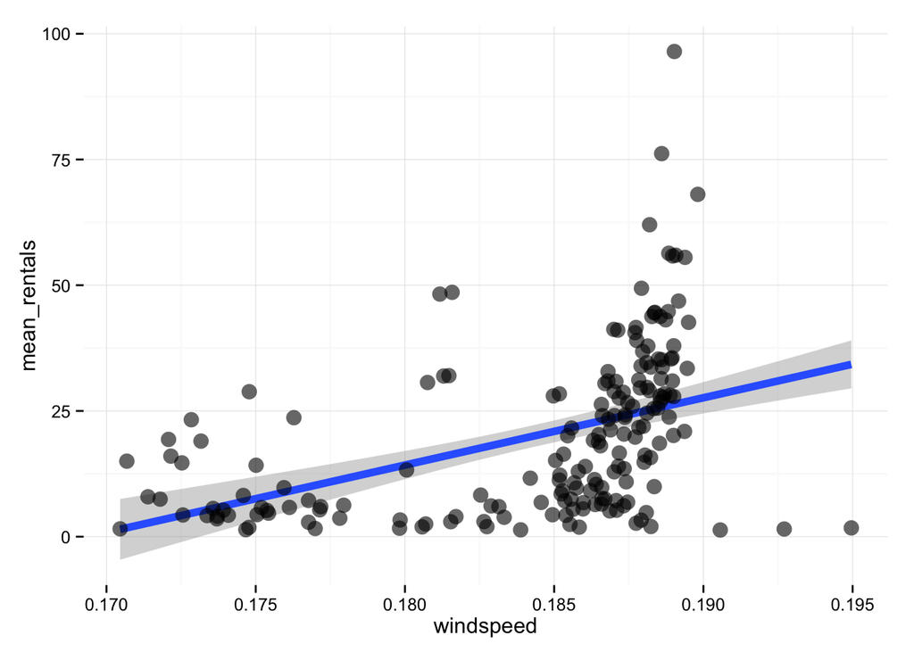

```r
ggplot(rentals_multi, aes(x = windspeed, y = mean_rentals)) +
  geom_smooth(method = 'lm', size = 2) +
  geom_point(size = 4, alpha = 0.60) +
  theme_minimal()
```

```r
model = lm(mean_rentals ~ crossing + windspeed, data = rentals_multi)
summary(model)
```

```
##
## Call:
## lm(formula = mean_rentals ~ crossing + windspeed, data = rentals_multi)
##
## Residuals:
##     Min      1Q  Median      3Q     Max
## -26.454  -9.202  -1.752   5.080  59.203
##
## Coefficients:
##               Estimate Std. Error t value Pr(>|t|)
## (Intercept) -200.35799   34.20198  -5.858 2.15e-08 ***
## crossing       0.21373    0.03231   6.616 3.99e-10 ***
## windspeed   1172.33663  185.81081   6.309 2.07e-09 ***
## ---
## Signif. codes:  0 '***' 0.001 '**' 0.01 '*' 0.05 '.' 0.1 ' ' 1
##
## Residual standard error: 13.45 on 182 degrees of freedom
## Multiple R-squared:  0.3468, Adjusted R-squared:  0.3396
## F-statistic: 48.31 on 2 and 182 DF,  p-value: < 2.2e-16
```

The model coefficients changed quite a lot when we added in wind speed. The intercept is now negative, and the wind speed coefficient is huge! When interpreting coefficients, it’s important to keep the scale in mind. Wind speed ranges from 0.05 to 0.44 so when you multiply 1172 by 0.05 for example, you end up with about 60, which is within the range we’d expect.

Let’s try one more, this time we’ll include a factor variable.

```r
rentals_multi =
  data %>%
    group_by(station_start, is_work_day) %>%
    summarize(mean_rentals = mean(no_rentals),
              crossing = mean(crossing),
              windspeed = mean(windspeed))

head(rentals_multi)
```

```
## Source: local data frame [6 x 5]
## Groups: station_start
##
##         station_start is_work_day mean_rentals crossing windspeed
## 1      10th & E St NW           0    19.416667      122 0.1858375
## 2      10th & E St NW           1    18.804444      122 0.1670843
## 3 10th & Monroe St NE           0     5.854054        1 0.1912622
## 4 10th & Monroe St NE           1     8.584906        1 0.1838902
## 5      10th & U St NW           0    41.761062        5 0.1939839
## 6      10th & U St NW           1    36.088937        5 0.1865657
```

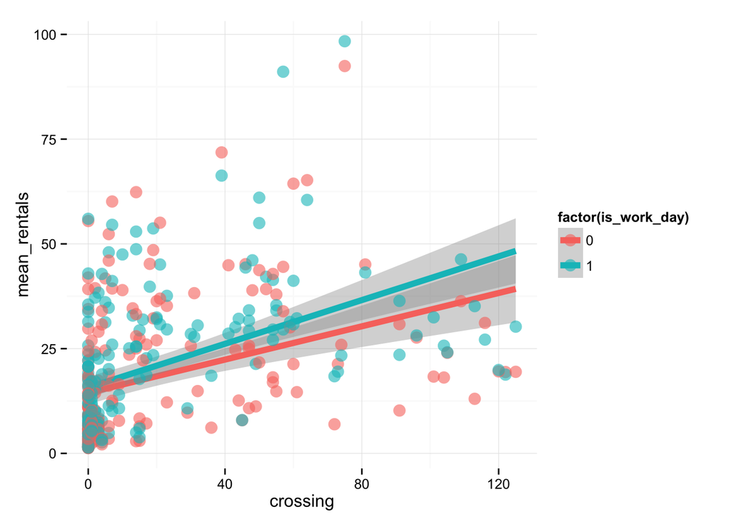

```r
# plot crossings, colored by is_work_day
ggplot(rentals_multi,
       aes(x = crossing, y = mean_rentals, color = factor(is_work_day))) +
  geom_smooth(method = 'lm', size = 2) +
  geom_point(size = 4, alpha = 0.60) +
  theme_minimal()
```

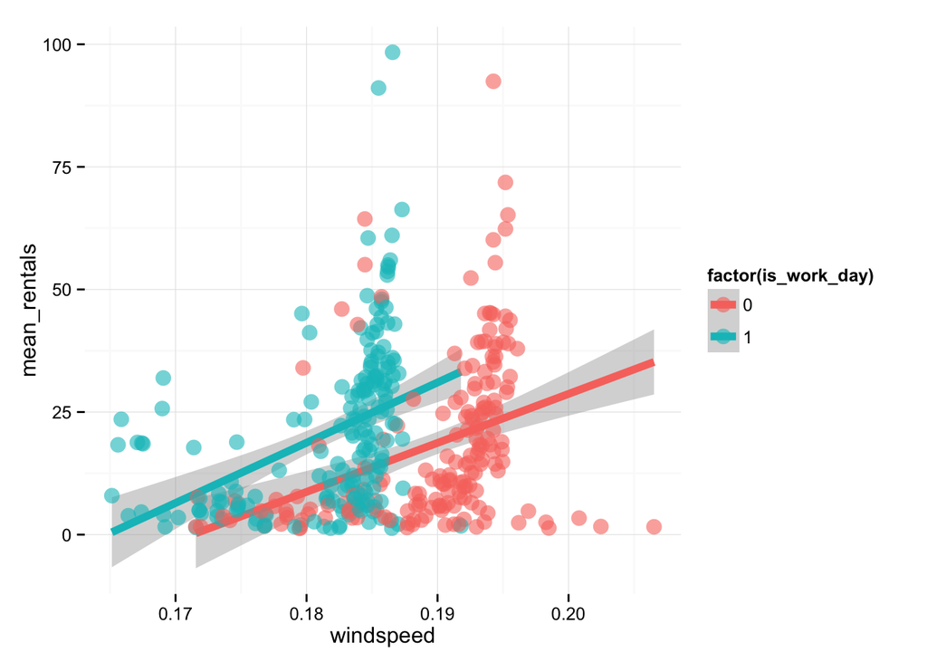

```r
# plot windspeed, colored by is_work_day
ggplot(rentals_multi,
       aes(x = windspeed, y = mean_rentals, color = factor(is_work_day))) +
  geom_smooth(method = 'lm', size = 2) +
  geom_point(size = 4, alpha = 0.60) +
  theme_minimal()
```

```r
model = lm(mean_rentals ~ crossing + windspeed + factor(is_work_day),
           data = rentals_multi)
summary(model)
```

```
##
## Call:
## lm(formula = mean_rentals ~ crossing + windspeed + factor(is_work_day),
##     data = rentals_multi)
##
## Residuals:
##     Min      1Q  Median      3Q     Max
## -28.943  -9.728  -2.500   5.734  61.718
##
## Coefficients:
##                        Estimate Std. Error t value Pr(>|t|)
## (Intercept)          -165.77396   24.38634  -6.798 4.33e-11 ***
## crossing                0.20358    0.02448   8.316 1.81e-15 ***
## windspeed             949.26045  128.75542   7.373 1.13e-12 ***
## factor(is_work_day)1   10.05016    1.81045   5.551 5.46e-08 ***
## ---
## Signif. codes:  0 '***' 0.001 '**' 0.01 '*' 0.05 '.' 0.1 ' ' 1
##
## Residual standard error: 14.39 on 366 degrees of freedom
## Multiple R-squared:  0.2868, Adjusted R-squared:  0.281
## F-statistic: 49.06 on 3 and 366 DF,  p-value: < 2.2e-16
```

## The *caret* package

We’ll be using the *caret* package (short for *c*lassification *a*nd *re*gression *t*raining) for model development because it integrates many modeling packages in R into one unified syntax. That means more reusable code for us! *caret* contains helper functions that provide a unified framework for data cleaning/splitting, model training, and comparison. I highly recommend the [optional reading](https://github.com/erinshellman/BI-TECH-CP303/blob/master/reading/regression/v28i05.pdf) this week which provides a great overview of the *caret* package.

```r
install.packages('caret', dependencies = TRUE)
library(caret)

set.seed(1234) # set a seed
```

Setting a seed in R insures that you get identical results each time you run your code. Since resampling methods are inherently probabilistic, every time we rerun them we’ll get slightly different answers. Setting the seed to the same number insures that we get identical randomness each time the code is run, and that’s helpful for debugging.

### Train and test data

Before any analysis in this class we’ll need to divide our data into train and test sets. Check out [this](http://topepo.github.io/caret/training.html) nice overview for more details. The *training* set is typically about 75% of the data and is used for all the model development. Once we have a model we’re satified with, we use our *testing* set, the other 25% to generate model predictions. Splitting the data into the two groups, train and test, generates two types of errors, in-sample and out-of-sample errors. *In-sample* errors are the errors derived from same data the model was built with. *Out-of-sample* errors are derived from measuring the error on a fresh data set. We are interested in the out-of-sample error because this quantity represents how’d we’d expect the model to perform in the future on brand new data.

Here’s how to split the data with *caret*:

```r
# select the training observations
in_train = createDataPartition(y = rentals_multi$mean_rentals,
                                   p = 0.75, # 75% in train, 25% in test
                                   list = FALSE)
head(in_train) # row indices of observations in the training set
```

```
##      Resample1
## [1,]        13
## [2,]        17
## [3,]        18
## [4,]        43
## [5,]        44
## [6,]        47
```

```r
train = rentals_multi[in_train, ]
test = rentals_multi[-in_train, ]

dim(train)
```

```
## [1] 278   5
```

```r
dim(test)
```

```
## [1] 92  5
```

Note: I recommend doing all data processing and aggregation steps *before* splitting out your train/test sets.

### Training

Our workhorse function in the *caret* package in the `train` function. This function can be used to evaluate performance parameters, choose optimal models based on the values of those parameters, and estimate model performance. For regression we can use it in place of the `lm()` function. Here’s our last regression model using the train function.

```r
model_fit = train(mean_rentals ~ crossing + windspeed + factor(is_work_day),
                  data = train,
                  method = 'lm',
                  metric = 'RMSE')
print(model_fit)
```

```
## Linear Regression
##
## 278 samples
##   4 predictor
##
## No pre-processing
## Resampling: Bootstrapped (25 reps)
##
## Summary of sample sizes: 278, 278, 278, 278, 278, 278, ...
##
## Resampling results
##
##   RMSE     Rsquared   RMSE SD   Rsquared SD
##   14.7152  0.3040576  1.650331  0.05201579
##
##
```

```r
summary(model_fit)
```

```
##
## Call:
## lm(formula = .outcome ~ ., data = dat)
##
## Residuals:
##     Min      1Q  Median      3Q     Max
## -28.864  -9.693  -2.593   5.484  60.520
##
## Coefficients:
##                          Estimate Std. Error t value Pr(>|t|)
## (Intercept)            -167.30868   29.42123  -5.687 3.32e-08 ***
## crossing                  0.22934    0.02948   7.778 1.50e-13 ***
## windspeed               957.58737  155.35778   6.164 2.53e-09 ***
## `factor(is_work_day)1`    9.29728    2.16565   4.293 2.45e-05 ***
## ---
## Signif. codes:  0 '***' 0.001 '**' 0.01 '*' 0.05 '.' 0.1 ' ' 1
##
## Residual standard error: 14.99 on 274 degrees of freedom
## Multiple R-squared:  0.2981, Adjusted R-squared:  0.2904
## F-statistic: 38.79 on 3 and 274 DF,  p-value: < 2.2e-16
```

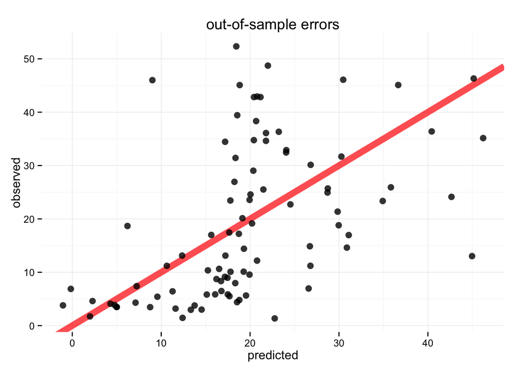

```r
# get predictions
out_of_sample_predictions = predict(model_fit, newdata = test)

# compare predictions against the observed values
errors = data.frame(predicted = out_of_sample_predictions,
                    observed = test$mean_rentals,
                    error = out_of_sample_predictions - test$mean_rentals)

# eh, not so good
ggplot(data = errors, aes(x = predicted, y = observed)) +
  geom_abline(aes(intercept = 0, slope = 1),
              size = 3, alpha = 0.70, color = 'red') +
  geom_point(size = 3, alpha = 0.80) +
  ggtitle('out-of-sample errors') +
  theme_minimal()
```

Our prediction accuracy is not so great for this model. The RMSE is about 15 which means that on average the predictions are off by about 15 rentals.

## Which model is the best?

Typically adding more predictors to a model will increase the $R^2$, so using that criteria alone will cause you to favor larger models.

## Project tips

We saw how to merge the datasets together into one, but it often makes sense to do some aggregation before merging. For example, since we know *usage* needs to be aggregated and summarized to remove the date variable, it makes sense to merge *usage* with the weather data and summarized before merging on the station data. For example:

```r
# we made this data frame in the merging section above
weather_rentals = merge(custs_per_day, weather,
                        by.x = 'time_start', by.y = 'date')

# group_by all the factors and summarize the continuous variables to generate
# a final data frame that can be merged by station.
model_data =
  weather_rentals %>%
    group_by(
      station_start,
      cust_type,
      weekday,
      season_code,
      is_holiday,
      is_work_day,
      weather_code) %>%
    summarize(
      rentals = mean(no_rentals),
      duration = mean(duration_mins),
      temp = mean(temp),
      subjective_temp = mean(subjective_temp),
      humidity = mean(humidity),
      windspeed = mean(windspeed))

head(model_data)
```

```
## Source: local data frame [6 x 13]
## Groups: station_start, cust_type, weekday, season_code, is_holiday, is_work_day
##
##    station_start cust_type weekday season_code is_holiday is_work_day
## 1 10th & E St NW    Casual       0           1          0           0
## 2 10th & E St NW    Casual       0           3          0           0
## 3 10th & E St NW    Casual       0           3          0           0
## 4 10th & E St NW    Casual       0           4          0           0
## 5 10th & E St NW    Casual       0           4          0           0
## 6 10th & E St NW    Casual       1           1          0           1
## Variables not shown: weather_code (int), rentals (dbl), duration (dbl),
##   temp (dbl), subjective_temp (dbl), humidity (dbl), windspeed (dbl)
```

```r
# now merge on stations
final_data = merge(model_data, stations,
  by.x = 'station_start',
  by.y = 'station')

data = final_data
rm(final_data)

# remove variables from the data that won't be used for modeling, e.g. lat/long
data_to_model =
  data %>%
    select(-station_start, -id, -terminal_name, -lat, -long)

dim(data_to_model)
```

```
## [1] 23390   143
```

```r
head(data_to_model)
```

```
##   cust_type weekday season_code is_holiday is_work_day weather_code
## 1    Casual       2           3          0           1            2
## 2    Casual       2           4          0           1            1
## 3    Casual       2           4          0           1            2
## 4    Casual       3           3          0           1            1
## 5    Casual       3           3          0           1            2
## 6    Casual       3           4          0           1            1
##   rentals duration      temp subjective_temp  humidity windspeed no_bikes
## 1   10.50 19.77941 0.6795830       0.6313440 0.7881250 0.2372475        6
## 2   10.60 28.57302 0.4898332       0.4828182 0.6340000 0.1817242        6
## 3    5.40 22.91333 0.3618334       0.3523850 0.6985836 0.2297340        6
## 4   11.00 56.17625 0.6869446       0.6442257 0.6009258 0.1478740        6
## 5   23.00 54.26087 0.7500000       0.7077170 0.6729170 0.1107000        6
## 6    7.75 28.51447 0.4507291       0.4406516 0.6083854 0.1771694        6
##   no_empty_docks fast_food parking restaurant convenience post_office
```

[output cut: 146 more lines]

```r
model = lm(rentals ~ ., data = data_to_model)
summary(model)
```

```
##
## Call:
## lm(formula = rentals ~ ., data = data_to_model)
##
## Residuals:
##     Min      1Q  Median      3Q     Max
## -67.933 -11.365  -0.838   8.980 222.391
##
## Coefficients: (23 not defined because of singularities)
##                            Estimate Std. Error t value Pr(>|t|)
## (Intercept)              -1.737e+01  1.618e+00 -10.740  < 2e-16 ***
## cust_typeRegistered       2.755e+01  2.854e-01  96.523  < 2e-16 ***
## cust_typeSubscriber       1.603e+01  4.039e-01  39.699  < 2e-16 ***
## weekday                   6.292e-01  6.487e-02   9.700  < 2e-16 ***
## season_code              -5.139e-01  1.404e-01  -3.662 0.000251 ***
## is_holiday               -3.132e+00  4.912e-01  -6.376 1.85e-10 ***
## is_work_day               2.061e+00  2.851e-01   7.231 4.94e-13 ***
## weather_code             -3.945e+00  4.162e-01  -9.479  < 2e-16 ***
## duration                  8.699e-04  4.891e-04   1.779 0.075313 .
## temp                     -1.483e+02  1.087e+01 -13.637  < 2e-16 ***
## subjective_temp           1.700e+02  1.262e+01  13.464  < 2e-16 ***
## humidity                 -7.251e-01  2.299e+00  -0.315 0.752438
## windspeed                -1.540e+01  2.692e+00  -5.719 1.08e-08 ***
## no_bikes                  8.066e-01  3.916e-02  20.597  < 2e-16 ***
## no_empty_docks            6.027e-01  3.984e-02  15.129  < 2e-16 ***
## fast_food                 4.224e-01  1.623e-01   2.602 0.009271 **
## parking                  -1.321e+00  3.253e-01  -4.062 4.89e-05 ***
## restaurant                1.273e-01  6.479e-02   1.965 0.049453 *
## convenience              -2.393e+01  2.985e+00  -8.016 1.14e-15 ***
## post_office               7.823e-02  6.808e-01   0.115 0.908520
## bicycle_parking          -2.040e+00  5.089e-01  -4.008 6.14e-05 ***
## drinking_water            1.715e+00  3.819e-01   4.490 7.15e-06 ***
## recycling                -6.329e+00  1.719e+00  -3.681 0.000233 ***
## waste_basket              1.243e+00  2.504e-01   4.963 6.98e-07 ***
## waste_disposal                   NA         NA      NA       NA
## cafe                      6.801e-01  2.560e-01   2.656 0.007902 **
## currency_exchange         3.960e+01  2.482e+00  15.957  < 2e-16 ***
## fountain                  3.233e+00  6.346e-01   5.095 3.52e-07 ***
## ice_cream                        NA         NA      NA       NA
## optician                         NA         NA      NA       NA
```

[output cut: 105 more lines]

```
## sculpture                -1.059e+00  6.480e-01  -1.634 0.102320
## hostel                   -3.427e+01  4.472e+00  -7.662 1.90e-14 ***
## picnic_site               8.514e-01  8.184e-01   1.040 0.298183
## tour_guide               -6.260e+00  4.253e+00  -1.472 0.141051
## attraction               -3.065e+00  5.734e-01  -5.344 9.17e-08 ***
## landmark                 -1.204e+01  2.057e+00  -5.853 4.91e-09 ***
## motel                    -9.610e+00  2.864e+00  -3.355 0.000794 ***
## guest_house              -1.725e+01  3.620e+00  -4.765 1.90e-06 ***
## gallery                  -2.234e-01  1.108e+00  -0.202 0.840265
## ---
## Signif. codes:  0 '***' 0.001 '**' 0.01 '*' 0.05 '.' 0.1 ' ' 1
##
## Residual standard error: 18.97 on 23269 degrees of freedom
## Multiple R-squared:  0.5252, Adjusted R-squared:  0.5227
## F-statistic: 214.5 on 120 and 23269 DF,  p-value: < 2.2e-16
```

```r
# hmm, we have some weirdness in there, some stations features don't exist
# around any of our stations, e.g. 'turning_loop'
table(data_to_model$turning_loop)
```

```
##
##     0
## 23390
```

```r
# lets remove those using the handly 'colSums' and 'which' functions
colSums(data_to_model[ , 15:143])
```

```
##                fast_food                  parking               restaurant
##                    41155                    15531                   112007
##              convenience              post_office          bicycle_parking
##                      684                     5156                     6528
##           drinking_water                recycling             waste_basket
##                     7462                      968                     7036
##           waste_disposal                     cafe        currency_exchange
##                        0                    42066                      150
##                 fountain                ice_cream                 optician
##                     2387                        0                        0
##                 pharmacy            tanning_salon              car_sharing
##                     8493                        0                      564
##                  alcohol                     bank                      bar
##                      294                    37061                    18419
##                     club                  embassy               food_court
##                      677                     3062                     1003
##               government    internal_kindergarten             kindergarten
##                      551                      381                     5492
##         place_of_worship                 post_box                      pub
##                    21231                    10382                    17565
##          vending_machine                     fuel               grave_yard
##                      381                     1695                     1154
##          public_building                   school             fire_station
##                     2560                    17131                     1532
##                nightclub                      atm                 hospital
##                     2472                     2122                      779
##                  doctors                  theatre               university
##                     1955                     2777                      721
##                    clock         parking_entrance                   police
##                      238                     1167                     1232
##          cultural_center                stripclub              marketplace
##                      297                      295                     1195
##              dry_cleaner   bicycle_repair_station                   office
##                      354                      876                      533
##              arts_centre                  library                   studio
##                     2219                     1390                      282
##               strip_club                  tourist               veterinary
##                      382                     2719                      741
##         community_centre           compressed_air                    tutor
##                      300                      302                      300
```

[output cut: 31 more lines]

```
##                    33156                      148                        0
##                     stop           turning_circle                 elevator
##                    25580                     1276                      150
## traffic_signals.bus_stop          mini_roundabout                  footway
##                      144                      335                       98
##              street_lamp             turning_loop                    hotel
##                      150                        0                    15907
##                  artwork              information                   museum
##                    12172                     2117                     2762
##                sculpture                   hostel              picnic_site
##                      564                      533                      569
##               tour_guide               attraction                 landmark
##                      239                     2423                      268
##                    motel              guest_house                  gallery
##                       73                       56                     1187
```

```r
# we want to know 'which' columns have a sum of 0
columns_to_remove = names(which(colSums(data_to_model[ , 15:143]) == 0))

# now combine that with filter to remove those from our data
data_to_model = data_to_model[ , !(names(data_to_model) %in% columns_to_remove)]

# try the model again
model = lm(rentals ~ ., data = data_to_model)
summary(model)
```

```
##
## Call:
## lm(formula = rentals ~ ., data = data_to_model)
##
## Residuals:
##     Min      1Q  Median      3Q     Max
## -67.933 -11.365  -0.838   8.980 222.391
##
## Coefficients: (5 not defined because of singularities)
##                            Estimate Std. Error t value Pr(>|t|)
## (Intercept)              -1.737e+01  1.618e+00 -10.740  < 2e-16 ***
## cust_typeRegistered       2.755e+01  2.854e-01  96.523  < 2e-16 ***
## cust_typeSubscriber       1.603e+01  4.039e-01  39.699  < 2e-16 ***
## weekday                   6.292e-01  6.487e-02   9.700  < 2e-16 ***
## season_code              -5.139e-01  1.404e-01  -3.662 0.000251 ***
## is_holiday               -3.132e+00  4.912e-01  -6.376 1.85e-10 ***
## is_work_day               2.061e+00  2.851e-01   7.231 4.94e-13 ***
## weather_code             -3.945e+00  4.162e-01  -9.479  < 2e-16 ***
## duration                  8.699e-04  4.891e-04   1.779 0.075313 .
## temp                     -1.483e+02  1.087e+01 -13.637  < 2e-16 ***
## subjective_temp           1.700e+02  1.262e+01  13.464  < 2e-16 ***
## humidity                 -7.251e-01  2.299e+00  -0.315 0.752438
## windspeed                -1.540e+01  2.692e+00  -5.719 1.08e-08 ***
## no_bikes                  8.066e-01  3.916e-02  20.597  < 2e-16 ***
## no_empty_docks            6.027e-01  3.984e-02  15.129  < 2e-16 ***
## fast_food                 4.224e-01  1.623e-01   2.602 0.009271 **
## parking                  -1.321e+00  3.253e-01  -4.062 4.89e-05 ***
## restaurant                1.273e-01  6.479e-02   1.965 0.049453 *
## convenience              -2.393e+01  2.985e+00  -8.016 1.14e-15 ***
## post_office               7.823e-02  6.808e-01   0.115 0.908520
## bicycle_parking          -2.040e+00  5.089e-01  -4.008 6.14e-05 ***
## drinking_water            1.715e+00  3.819e-01   4.490 7.15e-06 ***
## recycling                -6.329e+00  1.719e+00  -3.681 0.000233 ***
## waste_basket              1.243e+00  2.504e-01   4.963 6.98e-07 ***
## cafe                      6.801e-01  2.560e-01   2.656 0.007902 **
## currency_exchange         3.960e+01  2.482e+00  15.957  < 2e-16 ***
## fountain                  3.233e+00  6.346e-01   5.095 3.52e-07 ***
## pharmacy                  1.131e+00  6.380e-01   1.772 0.076344 .
## car_sharing               2.301e+00  1.083e+00   2.124 0.033657 *
## alcohol                   3.924e+00  2.349e+00   1.670 0.094870 .
```

[output cut: 87 more lines]

```
## sculpture                -1.059e+00  6.480e-01  -1.634 0.102320
## hostel                   -3.427e+01  4.472e+00  -7.662 1.90e-14 ***
## picnic_site               8.514e-01  8.184e-01   1.040 0.298183
## tour_guide               -6.260e+00  4.253e+00  -1.472 0.141051
## attraction               -3.065e+00  5.734e-01  -5.344 9.17e-08 ***
## landmark                 -1.204e+01  2.057e+00  -5.853 4.91e-09 ***
## motel                    -9.610e+00  2.864e+00  -3.355 0.000794 ***
## guest_house              -1.725e+01  3.620e+00  -4.765 1.90e-06 ***
## gallery                  -2.234e-01  1.108e+00  -0.202 0.840265
## ---
## Signif. codes:  0 '***' 0.001 '**' 0.01 '*' 0.05 '.' 0.1 ' ' 1
##
## Residual standard error: 18.97 on 23269 degrees of freedom
## Multiple R-squared:  0.5252, Adjusted R-squared:  0.5227
## F-statistic: 214.5 on 120 and 23269 DF,  p-value: < 2.2e-16
```

```r
# definintely better, but we still have some weird NAs, lets troubleshoot those
table(data_to_model$vending_machine)
```

```
##
##     0     1
## 23009   381
```

```r
table(data_to_model$storage)
```

```
##
##     0     1
## 23245   145
```

```r
table(data_to_model$dojo)
```

```
##
##     0     1
## 23243   147
```

```r
table(data_to_model$tax_service)
```

```
##
##     0     1
## 23243   147
```

```r
table(data_to_model$telephone)
```

```
##
##     0     1
## 23251   139
```

```r
# all the landmarks have at most 1 in the area, so there are not enough
# observations for least square to fit the model.
# these variables won't be helpful in prediction, so lets remove them.

data_to_model =
  data_to_model %>%
  select(
    -vending_machine,
    -storage,
    -dojo,
    -tax_service,
    -telephone)

# try the model again
model = lm(rentals ~ ., data = data_to_model)
summary(model)
```

```
##
## Call:
## lm(formula = rentals ~ ., data = data_to_model)
##
## Residuals:
##     Min      1Q  Median      3Q     Max
## -67.933 -11.365  -0.838   8.980 222.391
##
## Coefficients:
##                            Estimate Std. Error t value Pr(>|t|)
## (Intercept)              -1.737e+01  1.618e+00 -10.740  < 2e-16 ***
## cust_typeRegistered       2.755e+01  2.854e-01  96.523  < 2e-16 ***
## cust_typeSubscriber       1.603e+01  4.039e-01  39.699  < 2e-16 ***
## weekday                   6.292e-01  6.487e-02   9.700  < 2e-16 ***
## season_code              -5.139e-01  1.404e-01  -3.662 0.000251 ***
## is_holiday               -3.132e+00  4.912e-01  -6.376 1.85e-10 ***
## is_work_day               2.061e+00  2.851e-01   7.231 4.94e-13 ***
## weather_code             -3.945e+00  4.162e-01  -9.479  < 2e-16 ***
## duration                  8.699e-04  4.891e-04   1.779 0.075313 .
## temp                     -1.483e+02  1.087e+01 -13.637  < 2e-16 ***
## subjective_temp           1.700e+02  1.262e+01  13.464  < 2e-16 ***
## humidity                 -7.251e-01  2.299e+00  -0.315 0.752438
## windspeed                -1.540e+01  2.692e+00  -5.719 1.08e-08 ***
## no_bikes                  8.066e-01  3.916e-02  20.597  < 2e-16 ***
## no_empty_docks            6.027e-01  3.984e-02  15.129  < 2e-16 ***
## fast_food                 4.224e-01  1.623e-01   2.602 0.009271 **
## parking                  -1.321e+00  3.253e-01  -4.062 4.89e-05 ***
## restaurant                1.273e-01  6.479e-02   1.965 0.049453 *
## convenience              -2.393e+01  2.985e+00  -8.016 1.14e-15 ***
## post_office               7.823e-02  6.808e-01   0.115 0.908520
## bicycle_parking          -2.040e+00  5.089e-01  -4.008 6.14e-05 ***
## drinking_water            1.715e+00  3.819e-01   4.490 7.15e-06 ***
## recycling                -6.329e+00  1.719e+00  -3.681 0.000233 ***
## waste_basket              1.243e+00  2.504e-01   4.963 6.98e-07 ***
## cafe                      6.801e-01  2.560e-01   2.656 0.007902 **
## currency_exchange         3.960e+01  2.482e+00  15.957  < 2e-16 ***
## fountain                  3.233e+00  6.346e-01   5.095 3.52e-07 ***
## pharmacy                  1.131e+00  6.380e-01   1.772 0.076344 .
## car_sharing               2.301e+00  1.083e+00   2.124 0.033657 *
## alcohol                   3.924e+00  2.349e+00   1.670 0.094870 .
```

[output cut: 82 more lines]

```
## sculpture                -1.059e+00  6.480e-01  -1.634 0.102320
## hostel                   -3.427e+01  4.472e+00  -7.662 1.90e-14 ***
## picnic_site               8.514e-01  8.184e-01   1.040 0.298183
## tour_guide               -6.260e+00  4.253e+00  -1.472 0.141051
## attraction               -3.065e+00  5.734e-01  -5.344 9.17e-08 ***
## landmark                 -1.204e+01  2.057e+00  -5.853 4.91e-09 ***
## motel                    -9.610e+00  2.864e+00  -3.355 0.000794 ***
## guest_house              -1.725e+01  3.620e+00  -4.765 1.90e-06 ***
## gallery                  -2.234e-01  1.108e+00  -0.202 0.840265
## ---
## Signif. codes:  0 '***' 0.001 '**' 0.01 '*' 0.05 '.' 0.1 ' ' 1
##
## Residual standard error: 18.97 on 23269 degrees of freedom
## Multiple R-squared:  0.5252, Adjusted R-squared:  0.5227
## F-statistic: 214.5 on 120 and 23269 DF,  p-value: < 2.2e-16
```

```r
# one last modification. our categorical variables are being treated like
# they're continuous. lets create some factors
data_to_model$weekday = factor(data_to_model$weekday,
                               labels = 0:6,
                               levels = 0:6)
data_to_model$season_code = factor(data_to_model$season_code)
data_to_model$is_holiday = factor(data_to_model$is_holiday)
data_to_model$is_work_day = factor(data_to_model$is_work_day)
data_to_model$weather_code = factor(data_to_model$weather_code)

# try the model again
model = lm(rentals ~ ., data = data_to_model)
summary(model)
```

```
##
## Call:
## lm(formula = rentals ~ ., data = data_to_model)
##
## Residuals:
##     Min      1Q  Median      3Q     Max
## -68.437 -11.258  -0.955   8.856 216.911
##
## Coefficients: (1 not defined because of singularities)
##                            Estimate Std. Error t value Pr(>|t|)
## (Intercept)              -2.735e+01  1.835e+00 -14.908  < 2e-16 ***
## cust_typeRegistered       2.732e+01  2.849e-01  95.899  < 2e-16 ***
## cust_typeSubscriber       1.615e+01  4.026e-01  40.109  < 2e-16 ***
## weekday1                  2.304e+00  4.708e-01   4.893 1.00e-06 ***
## weekday2                  1.862e+00  4.875e-01   3.820 0.000134 ***
## weekday3                  2.734e+00  4.976e-01   5.495 3.95e-08 ***
## weekday4                  2.244e+00  4.886e-01   4.593 4.40e-06 ***
## weekday5                  4.683e+00  5.130e-01   9.129  < 2e-16 ***
## weekday6                  3.474e+00  4.690e-01   7.408 1.33e-13 ***
## season_code2             -7.723e+00  6.074e-01 -12.715  < 2e-16 ***
## season_code3             -1.244e+01  8.393e-01 -14.820  < 2e-16 ***
## season_code4             -4.512e+00  4.975e-01  -9.069  < 2e-16 ***
## is_holiday1              -5.004e+00  4.779e-01 -10.472  < 2e-16 ***
## is_work_day1                     NA         NA      NA       NA
## weather_code2            -2.382e+00  4.441e-01  -5.363 8.28e-08 ***
## weather_code3            -9.405e+00  9.631e-01  -9.766  < 2e-16 ***
## duration                  8.655e-04  4.863e-04   1.780 0.075122 .
## temp                     -9.362e+01  1.273e+01  -7.353 2.00e-13 ***
## subjective_temp           1.369e+02  1.437e+01   9.525  < 2e-16 ***
## humidity                 -2.456e+00  2.304e+00  -1.066 0.286593
## windspeed                -1.303e+01  2.845e+00  -4.581 4.66e-06 ***
## no_bikes                  8.103e-01  3.893e-02  20.814  < 2e-16 ***
## no_empty_docks            6.043e-01  3.961e-02  15.257  < 2e-16 ***
## fast_food                 4.193e-01  1.614e-01   2.598 0.009379 **
## parking                  -1.338e+00  3.234e-01  -4.137 3.53e-05 ***
## restaurant                1.306e-01  6.441e-02   2.027 0.042667 *
## convenience              -2.416e+01  2.967e+00  -8.143 4.05e-16 ***
## post_office               2.378e-01  6.769e-01   0.351 0.725334
## bicycle_parking          -2.052e+00  5.059e-01  -4.056 5.02e-05 ***
## drinking_water            1.743e+00  3.797e-01   4.591 4.43e-06 ***
```

[output cut: 90 more lines]

```
## sculpture                -1.064e+00  6.442e-01  -1.652 0.098473 .
## hostel                   -3.463e+01  4.447e+00  -7.789 7.04e-15 ***
## picnic_site               9.181e-01  8.136e-01   1.128 0.259135
## tour_guide               -6.177e+00  4.228e+00  -1.461 0.144003
## attraction               -3.069e+00  5.701e-01  -5.384 7.36e-08 ***
## landmark                 -1.171e+01  2.045e+00  -5.725 1.05e-08 ***
## motel                    -8.991e+00  2.848e+00  -3.157 0.001597 **
## guest_house              -1.726e+01  3.599e+00  -4.796 1.63e-06 ***
## gallery                  -1.239e-01  1.102e+00  -0.112 0.910451
## ---
## Signif. codes:  0 '***' 0.001 '**' 0.01 '*' 0.05 '.' 0.1 ' ' 1
##
## Residual standard error: 18.85 on 23262 degrees of freedom
## Multiple R-squared:  0.5309, Adjusted R-squared:  0.5283
## F-statistic: 207.3 on 127 and 23262 DF,  p-value: < 2.2e-16
```

```r
# now 'is_work_day1' is NA, what gives?! remember the assumptions of linear
# regression. our covariates must be independent - that is, not correlated. in
# this case if you know the values of weekday, you know the value of
# is_work_day so that assumption doesn't hold. get rid of it!
data_to_model$is_work_day = NULL

# try the model again
model = lm(rentals ~ ., data = data_to_model)
summary(model)
```

```
##
## Call:
## lm(formula = rentals ~ ., data = data_to_model)
##
## Residuals:
##     Min      1Q  Median      3Q     Max
## -68.437 -11.258  -0.955   8.856 216.911
##
## Coefficients:
##                            Estimate Std. Error t value Pr(>|t|)
## (Intercept)              -2.735e+01  1.835e+00 -14.908  < 2e-16 ***
## cust_typeRegistered       2.732e+01  2.849e-01  95.899  < 2e-16 ***
## cust_typeSubscriber       1.615e+01  4.026e-01  40.109  < 2e-16 ***
## weekday1                  2.304e+00  4.708e-01   4.893 1.00e-06 ***
## weekday2                  1.862e+00  4.875e-01   3.820 0.000134 ***
## weekday3                  2.734e+00  4.976e-01   5.495 3.95e-08 ***
## weekday4                  2.244e+00  4.886e-01   4.593 4.40e-06 ***
## weekday5                  4.683e+00  5.130e-01   9.129  < 2e-16 ***
## weekday6                  3.474e+00  4.690e-01   7.408 1.33e-13 ***
## season_code2             -7.723e+00  6.074e-01 -12.715  < 2e-16 ***
## season_code3             -1.244e+01  8.393e-01 -14.820  < 2e-16 ***
## season_code4             -4.512e+00  4.975e-01  -9.069  < 2e-16 ***
## is_holiday1              -5.004e+00  4.779e-01 -10.472  < 2e-16 ***
## weather_code2            -2.382e+00  4.441e-01  -5.363 8.28e-08 ***
## weather_code3            -9.405e+00  9.631e-01  -9.766  < 2e-16 ***
## duration                  8.655e-04  4.863e-04   1.780 0.075122 .
## temp                     -9.362e+01  1.273e+01  -7.353 2.00e-13 ***
## subjective_temp           1.369e+02  1.437e+01   9.525  < 2e-16 ***
## humidity                 -2.456e+00  2.304e+00  -1.066 0.286593
## windspeed                -1.303e+01  2.845e+00  -4.581 4.66e-06 ***
## no_bikes                  8.103e-01  3.893e-02  20.814  < 2e-16 ***
## no_empty_docks            6.043e-01  3.961e-02  15.257  < 2e-16 ***
## fast_food                 4.193e-01  1.614e-01   2.598 0.009379 **
## parking                  -1.338e+00  3.234e-01  -4.137 3.53e-05 ***
## restaurant                1.306e-01  6.441e-02   2.027 0.042667 *
## convenience              -2.416e+01  2.967e+00  -8.143 4.05e-16 ***
## post_office               2.378e-01  6.769e-01   0.351 0.725334
## bicycle_parking          -2.052e+00  5.059e-01  -4.056 5.02e-05 ***
## drinking_water            1.743e+00  3.797e-01   4.591 4.43e-06 ***
## recycling                -5.961e+00  1.710e+00  -3.487 0.000490 ***
```

[output cut: 89 more lines]

```
## sculpture                -1.064e+00  6.442e-01  -1.652 0.098473 .
## hostel                   -3.463e+01  4.447e+00  -7.789 7.04e-15 ***
## picnic_site               9.181e-01  8.136e-01   1.128 0.259135
## tour_guide               -6.177e+00  4.228e+00  -1.461 0.144003
## attraction               -3.069e+00  5.701e-01  -5.384 7.36e-08 ***
## landmark                 -1.171e+01  2.045e+00  -5.725 1.05e-08 ***
## motel                    -8.991e+00  2.848e+00  -3.157 0.001597 **
## guest_house              -1.726e+01  3.599e+00  -4.796 1.63e-06 ***
## gallery                  -1.239e-01  1.102e+00  -0.112 0.910451
## ---
## Signif. codes:  0 '***' 0.001 '**' 0.01 '*' 0.05 '.' 0.1 ' ' 1
##
## Residual standard error: 18.85 on 23262 degrees of freedom
## Multiple R-squared:  0.5309, Adjusted R-squared:  0.5283
## F-statistic: 207.3 on 127 and 23262 DF,  p-value: < 2.2e-16
```

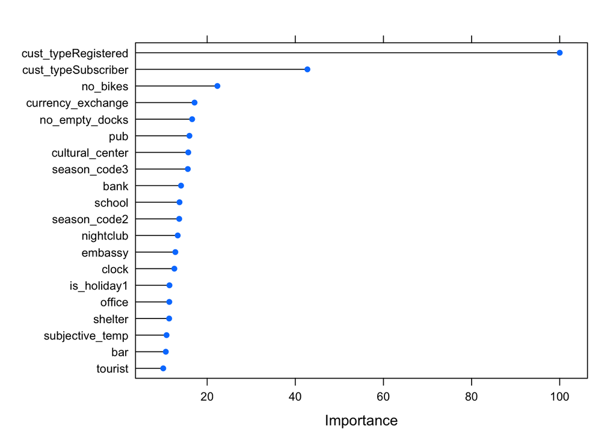

```r
# ok, we've successfully hit a model but boy does it have a lot of predictors
# lets start evaluating the predictive accuracy

# select the training observations
in_train = createDataPartition(y = data_to_model$rentals,
                                   p = 0.75,
                                   list = FALSE)

train = data_to_model[in_train, ]
test = data_to_model[-in_train, ]

# when we train with the lm function, we get the same results as using lm()
model_fit = train(rentals ~ .,
                  data = train,
                  method = 'lm',
                  metric = 'RMSE')

# view the relative importance of the predictors
plot(varImp(model_fit), top = 20)
```

```r
rentals_predicted = predict(model_fit, newdata = test)

prediction = data.frame(rentals_predicted,
                        rentals_observed = test$rentals,
                        error = rentals_predicted - test$rentals)
summary(prediction$error)
```

```
##       Min.    1st Qu.     Median       Mean    3rd Qu.       Max.
## -165.70000   -9.01200    0.78830   -0.00479   11.35000   61.02000
```

```
## geom_smooth: method="auto" and size of largest group is >=1000, so using gam with formula: y ~ s(x, bs = "cs"). Use 'method = x' to change the smoothing method.
```

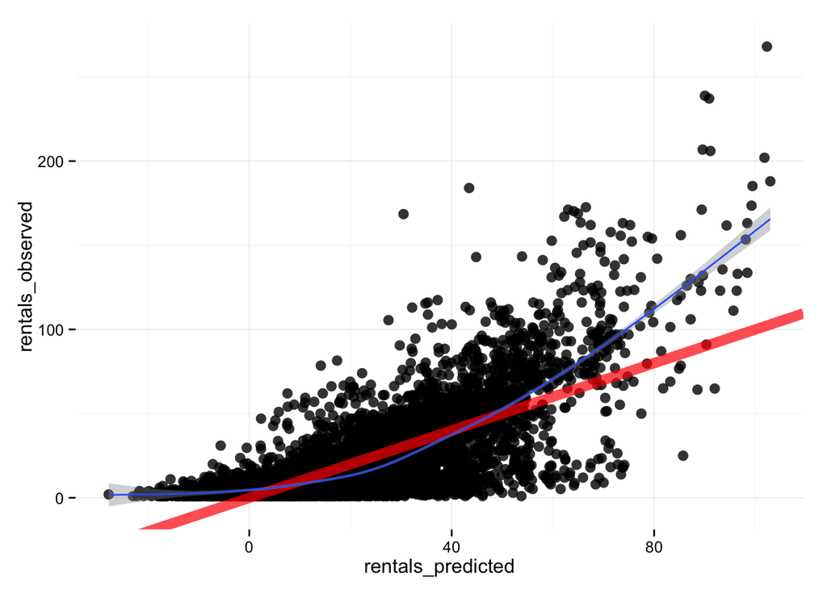

```r
ggplot(data = prediction, aes(x = rentals_predicted, y = rentals_observed)) +
  geom_point(size = 3, alpha = 0.80) +
  geom_abline(aes(intercept = 0, slope = 1),
              size = 3, alpha = 0.70, color = 'red') +
  geom_smooth() +
  theme_minimal()
```

```
## geom_smooth: method="auto" and size of largest group is >=1000, so using gam with formula: y ~ s(x, bs = "cs"). Use 'method = x' to change the smoothing method.
```

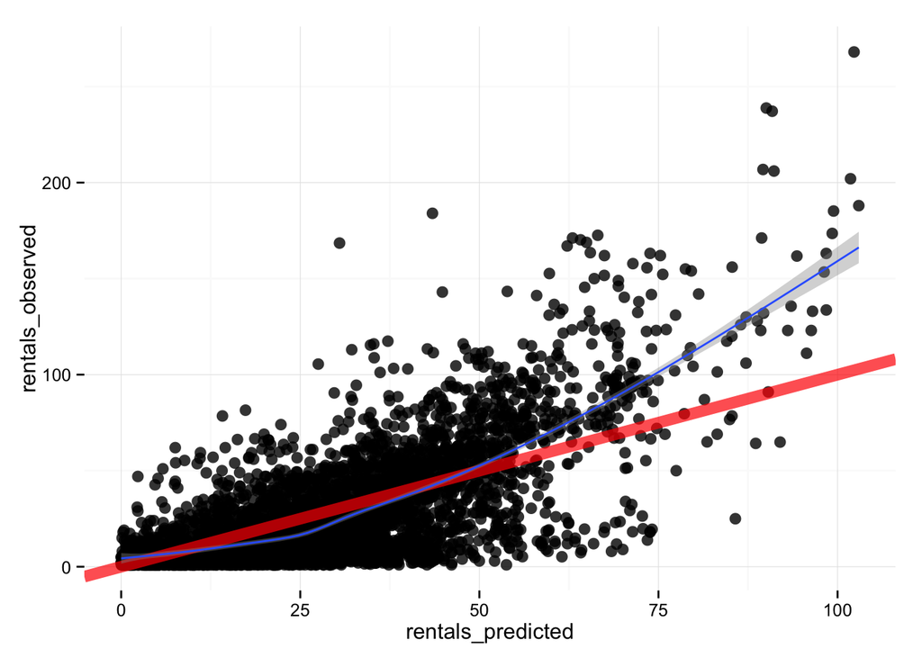

```r
ggplot(data = filter(prediction, rentals_predicted > 0), aes(x = rentals_predicted, y = rentals_observed)) +
  geom_point(size = 3, alpha = 0.80) +
  geom_abline(aes(intercept = 0, slope = 1),
              size = 3, alpha = 0.70, color = 'red') +
  geom_smooth() +
  theme_minimal()
```

```
## geom_smooth: method="auto" and size of largest group is >=1000, so using gam with formula: y ~ s(x, bs = "cs"). Use 'method = x' to change the smoothing method.
```

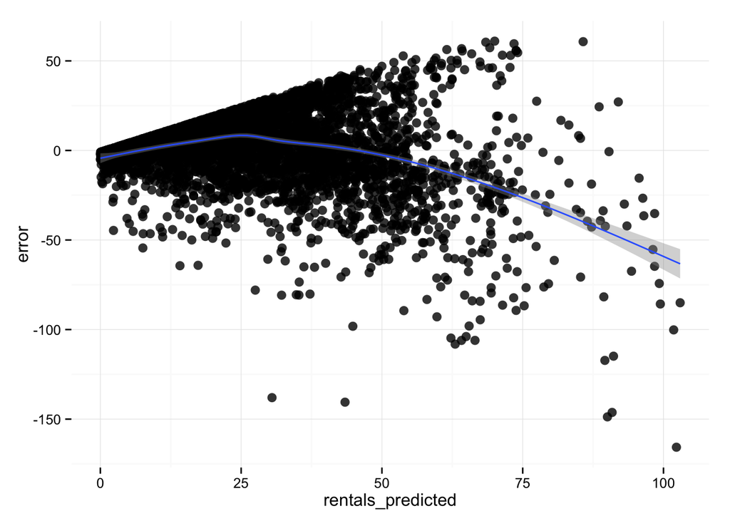

```r
ggplot(data = filter(prediction, rentals_predicted > 0), aes(x = rentals_predicted, y = error)) +
  geom_point(size = 3, alpha = 0.80) +
  geom_smooth() +
  theme_minimal()
```